# Lecture 8: From cryptography to cryptocurrencies

### Announcements

- Test 1 this Wednesday
  - Bring your BU ID and a pencil + eraser (or pen)
  - Do not bring any written materials or electronic aids (no calculators, cheat sheets, headphones, laptops, notes, phones, or textbooks)
- Reading: [NBFMG, sections 2.1-2-3](https://d28rh4a8wq0iu5.cloudfront.net/bitcointech/readings/princeton_bitcoin_book.pdf)
- No programming-based homework this week

### Learning outcomes

By the end of today’s lecture, you will learn:

- How cryptocurrencies allow people to broadcast and record financial payments on a “public ledger,” also known as a blockchain
- The role that hash functions and digital signatures play in the design of Bitcoin

### Review from previous lectures

A cryptographic **hash function** $H: \{0, 1\}^* \to \{0, 1\}^n$ is an efficiently-computable function that accepts *unbounded* input and that provides output strings of a *fixed* number of bits $n$. It satisfies the following requirements:

- *Preimage resistance*: given a uniformly random string $y \in \{0, 1\}^n$, it is practically infeasible for Mallory to find any preimage $x$ such that $H(x) = y$.
- *Collision resistance*: it is practically infeasible for Mallory to find two different inputs $x_1$ and $x_2$ such that $H(x_1) = H(x_2)$
- *Random oracle*: $H$ acts as if its truth table has random and independent rows

A **digital signature** provides three efficiently computable operations (`KeyGen`, `Sign`, and `Verify`) that satisfy the following requirements:

- *Correctness*: Alice’s honest signatures always pass the verification check
- *Unforgeability*: even after Mallory receives signatures on messages of her choice, it is computationally infeasible for her to forge a signature on a new message

These two cryptographic tools are all we need to build a **cryptocurrency** – a system for digital money.

## 8.1 Internet-based Money

**Warning**: The cryptocurrency market is incredibly volatile. Investing in cryptocurrencies is a bad way to make money, and a good way to lose money. **Do not invest in cryptocurrencies!**

With that warning stated: we’re going to explore the world of cryptocurrencies in Unit 2, for two reasons.

1. Cryptocurrencies build upon hash functions and digital signatures, and combine them in clever ways
2. Bitcoin combines clever techniques for *broadcast* and *leader election*, which we can apply to other problems that require reaching consensus over the Internet

Cryptocurrencies are an alternative banking system that works digitally, where people can transfer money to each other electronically over the Internet *without the need for a single trusted banking authority*.

Our digital money system should be “*secure*” against “*powerful adversaries*.” (We will make more precise today both the security requirements and the kinds of adversaries that we can withstand.)

In the physical world, when Bob receives a check from Alice, he may be suspicious that Alice is trying to deceive him. He needs to be able to verify the following three properties.

1. Alice properly signed the check
2. Alice possesses $1 in her bank account
3. Alice does not **double spend** the money by writing a check to someone else at the same time

[figure not shown]

For a digital monetary system:

- A digital signature scheme like RSA or ECDSA can satisfy objective #1, because signatures are *unforgeable*.
- To satisfy the other two objectives, it would help to have a digital version of a *ledger* that is available to everyone.

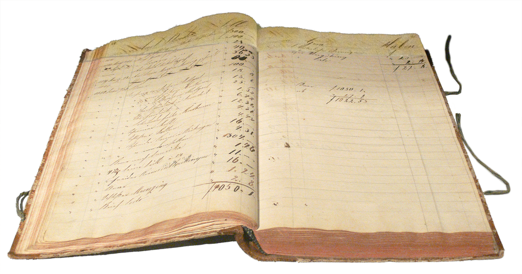

19th century ledger (source: [Wikipedia](https://en.wikipedia.org/wiki/General_ledger#/media/File:Ledger.png))

> A **ledger** is a book or collection of accounts in which account transactions are recorded. Each account has an opening or carry-forward balance, and would record each transaction as either a debit or credit in separate columns, and the ending or closing balance.

> For every debit recorded in a ledger, there must be a corresponding credit, so that the debits equal the credits in the grand totals.

> Source: [Wikipedia](https://en.wikipedia.org/wiki/Ledger)

Imagine for the moment that there was a book that is:

- **Public**, meaning that anyone can read it at any time.
- **Append-only**, meaning that:
  - Anyone can add new information at the end of the ledger, but
  - Nothing that is already in the ledger can ever be erased or overwritten.

If you had such a ledger, then you can emulate the bank!

## 8.2 Bitcoin’s Public Ledger

Bitcoin is a **public** and **peer-to-peer** cryptocurrency. It is a digital coin, combined with a digital ledger that keeps track of how many Bitcoins each party holds at any moment in time.

- Rather than relying on a bank, the ledger is maintained by *everyone* running the Bitcoin software
- Participants called **nodes** maintain *consensus* over this ledger
- The ledger is separated into **blocks**, and each **block** can contain many **transactions**
- These blocks are created by **miners**, and a new block is mined approximately every 10 minutes

Here are some recent blocks on the Bitcoin blockchain.

[figure not shown]

Blocks in the Bitcoin blockchain (source: mempool.space

### History

The data structure for Bitcoin’s public ledger is called a **blockchain**.

- It is a sequence of blocks, which themselves contain several transactions
- If everyone acts honestly, the intention is that new blocks are only added to the end of the chain

Bitcoin was invented in 2009 by an anonymous party (or parties) holding the pseudonym Satoshi Nakamato.

- While we will focus today on financial transactions, in principle you can store any data on Bitcoin.
- The first transaction on the Bitcoin blockchain encodes the following message: “The Times 03/Jan/2009 Chancellor on brink of second bailout for banks.” It is a reference to an article posted in a British newspaper on January 3, 2009.

[figure not shown]

The Times newspaper (source: [en.bitcoin.it](https://en.bitcoin.it/w/images/en/1/1d/Jonny1000thetimes.png))

Because the Bitcoin blockchain is public, anyone can read any message that has ever been stored on it. The following code connects to a Bitcoin node (hosted on mempool.space) and extracts the bytestring message written within the *genesis* (first) block in the miner’s *coinbase transaction*.

```python
import requests
from binascii import unhexlify

# getting the block id for the genesis block (block 0)
genesis_block_id = requests.get('https://mempool.space/api/block-height/0').text

# getting all the block transactions of block 0 and parsing it
response = requests.get('https://mempool.space/api/block/'+genesis_block_id+'/txs')

# decode the special message in the genesis block
print(unhexlify(response.json()[0]['vin'][0]['scriptsig_asm'].split(" ")[5]))
```

```
b'The Times 03/Jan/2009 Chancellor on brink of second bailout for banks'
```

But you don’t have to trust the mempool.space website. Anyone can run the Bitcoin software and join the peer-to-peer network to see these blocks and transactions as they appear.

**Interactive question.** Which data structure corresponds to a single financial payment of Bitcoins?

1. Block
2. Blockchain
3. Transaction

## 8.3 Bitcoin transactions

A Bitcoin **transaction** is a single money transfer, somewhat like a written check from a sender to a receiver. But unlike a check:

- There can be more than one sender or receiver
- We write the sender and receiver’s public keys, rather than their real-world identities
- Transactions are **irrevocable**: if you make a mistake and send your money to the wrong place, it is gone forever!

If you have a public ledger, then there are two ways to record financial transactions.

1. Record the current owner of each coin. This is called the **account model** and it is what the traditional banking system does. The bank maintains a list of every account and its account balance. When a transaction is submitted, the bank updates its account ledger by debiting the sender and crediting the receiver.
2. Record the movement of each coin. This is called the **unspent transaction output** model, or UTXO. Bitcoin follows this approach by recording every financial transaction ever made.

In fact, you don’t even need to do both! Account balances can be inferred from the transaction list.

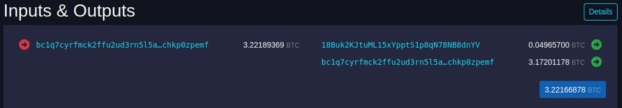

Bitcoin transaction

**Interactive question.** Suppose that Alice and Bob each start with $2, and Carol and David each start with $0. Then, the following transactions occur:

- Alice pays $1 to Bob
- Alice pays $1 to Carol
- Bob pays $1 to Carol
- Carol pays $1 to David
- Bob pays $1 to Alice
- David pays $1 to Bob
- Alice pays $1 to David

Who has the most money now?

1. Alice
2. Bob
3. Carol
4. David

### Transaction validity

In the UTXO model, for a transaction to be valid, the sender(s) must:

- Digitally sign the transaction
- Point to the prior transactions where they received the coins that are now being sent
- Not send out more money than they received in

If $\textit{in} > \textit{out}$, then a miner can claim the “leftover” money $\textit{in}-\textit{out}$ as a **transaction fee**.

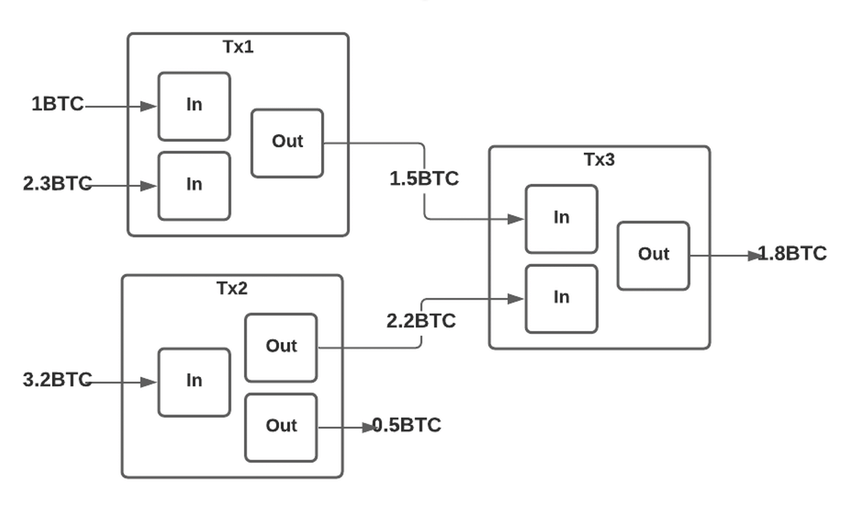

Bitcoin transactions (source: [researchgate.net](https://www.researchgate.net/publication/350479019/figure/fig3/AS:1023126523621376@1620943780846/Concept-of-Unspent-Transaction-Outputs-UTXOs.ppm))

### Pseudonymity

Transactions in Bitcoin are slightly different than checks in the physical world.

- Checks say “Alice hereby agrees to send 1 coin to Bob, signed Alice”
- Bitcoin transactions say “the person who holds the secret key corresponding to $\textit{pk}_{\textit{Alice}}$ hereby agrees to send 1 coin to the person who holds the secret key corresponding to public key $\textit{pk}_\textit{Bob}$, digitally signed with $\textit{sk}_{\textit{Alice}}$”

For this reason, we say that Bitcoin is **pseudonymous**.

- Real-world names are never directly posted on the public blockchain.
- However, as we will see later, Bitcoin is *not anonymous* because both people and money can be tracked over time.

Anyone who receives money in Bitcoin can send it out in a later transaction.

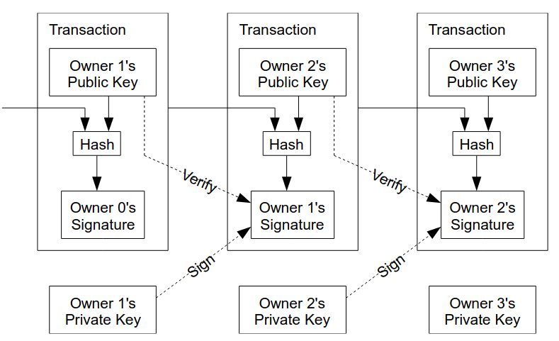

Example of Bitcoin transactions (source: [Nakamoto whitepaper](https://bitcoin.org/bitcoin.pdf))

Note: transactions in Bitcoin can be more complicated than a simple transfer of money. They can involve more sophisticated computer scripts that allow for conditional transfers.

### Broadcasting transactions

Recall that we previously studied the power of **common knowledge**.

- *Mutual knowledge* is information that everyone knows (like what happens at the start of the muddy children puzzle)
- *Common knowledge* is information that everyone knows, and everyone knows that everyone else knows, and everyone knows that everyone knows that everyone knows, and so on (like what happens at the end of the muddy children puzzle)

Suppose that Alice sends her signed transaction to every other computer over the Internet. Then:

- Everyone has the *mutual knowledge* that Alice wants to pay 1 coin to Bob
- But they do not yet have the *common knowledge* that everyone else knows, and everyone knows that everyone else knows, and so on

What happens if Alice only owns 1 coin, and she also broadcasts a transaction to pay 1 coin to Carol?

- We need a way to agree on the order of transactions and resolve conflicts
- But different people on the Internet can receive messages in different order

## 8.4 Bitcoin blocks

Bitcoin transactions are grouped into **blocks**.

- A block is limited in size to around 2 megabytes, which is enough space to store a few thousand transactions
- A new block is created approximately every 10 minutes

For instance, here is a block that was mined a few days ago.

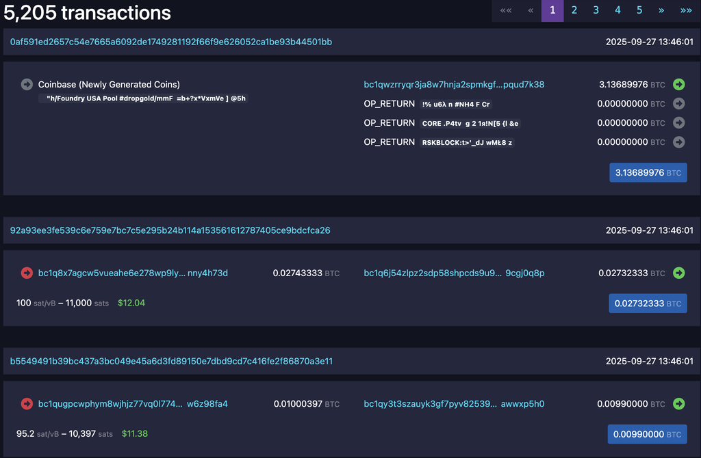

The blocks are linked together into a **blockchain**. Every block references the hash of the previous block. This data structure contains the entire Bitcoin ledger.

Some statistics about the size and scale of Bitcoin:

- To date, there are more than 900,000 blocks in the Bitcoin network.
- Collectively, they hold [more than 1.2 billion transactions](https://www.blockchain.com/explorer/charts/n-transactions-total).
- The blockchain is [around 689 GB](https://ycharts.com/indicators/bitcoin_blockchain_size) in size. (So anyone *can* download the ledger, but it might take awhile.)

### Consensus over blocks

The most important property of the Bitcoin blockchain is that all participants eventually reach **consensus** over the state of the ledger. If I believe that Alice owns 3 coins, then (eventually) so should you.

Consensus is ensured even if Mallory tries to:

- Tamper with the ledger (i.e., Bitcoin protects data integrity)
- Break or censor the ledger (i.e., Bitcoin protects data availability)

More specifically, we want a blockchain to achieve two types of consensus properties.

1. **Liveness**: Every valid transaction eventually makes it into some block
2. **Safety**: The contents of each block are eventually agreed upon by all honest participants in the Bitcoin network

Note the use of the word “eventually” in each claim. In future lectures, we will discuss how long “eventually” might take.

## 8.5 Participants in Bitcoin

At a high level, there are three types of participants within Bitcoin.

- A **light client** only needs to *hold* one or more secret keys for a digital signature scheme. (And optionally also a small amount of additional data, which we will discuss next week.)

  We consider the corresponding public key also to be their bank account number. These accounts might have money, if (1) someone else has sent money to this account within some transaction in the past and (2) no subsequent transaction has spent the money.
- A **node** additionally *stores* the entire state of the blockchain. (Note: this can be large! The Bitcoin blockchain is currently about [689 gigabytes in size](https://ycharts.com/indicators/bitcoin_blockchain_size).)
- A **miner** additionally tries to *write* new blocks on the blockchain. As we will see, the miner’s task requires substantial computing power.

Anyone can create a Bitcoin account and become a light client. All that is needed is a secret key and public key for a digital signature scheme like ECDSA or Schnorr signatures.

In the snippet of code below, we are creating an actual Bitcoin address right now! (But it has no money, since nobody has signed over their coins to us.)

This code is just for demonstration purposes. Do **NOT** execute this code to create a Bitcoin key in practice! This code makes no attempt to protect the secret key from being lost or stolen.

```python
# pip install "cryptos@git+https://github.com/nicolas3355/cryptos"

from cryptos.keys import gen_secret_key, PublicKey
from cryptos.bitcoin import BITCOIN

# generate a secret/public key pair
secret_key = gen_secret_key(BITCOIN.gen.n)
public_key = PublicKey.from_sk(secret_key)
print('generated secret key, in hex format:')
print(hex(secret_key))
print('\ncorresponding public key, as an elliptic curve point:')
print(public_key)

# get the associated bitcoin address
addr = public_key.address(net='main', compressed=True)
print('\ncompressed bitcoin address, in base 58 check format:')
print(addr)
```

```
generated secret key, in hex format:
0x328a422db57f0b78b354248a0c17b01f03c6d201b3d3da18d4fd557b17ab4f76

corresponding public key, as an elliptic curve point:
PublicKey(curve=Curve(p=115792089237316195423570985008687907853269984665640564039457584007908834671663, a=0, b=7), x=88357912016665238793579754283690471537071323568419220935980457329883588724367, y=74961479039233411511999240717285156910395998405370212936438686577839178416601)

compressed bitcoin address, in base 58 check format:
15Geb6VtzoWkx4jWN3jrJAtcjEgCh7WBHw
```

Whereas creating an account is easy, keeping track of this account is more difficult. If you accidentally delete your secret key, then you will never be able to spend the money in the account – effectively, your money is gone forever.

We will discuss in a future lecture how we can make it easier for people to keep track of their secret key(s) in a secure way.

### Role of a miner

Bitcoin needs miners: without them, no money transactions can ever be recorded. So the Bitcoin system incentivizes people to become miners. If you create or **mine** a new block, then you get two kinds of rewards:

1. You get to create new coins out of thin air. Specifically, you get 3.125 Bitcoins, which is worth about $340k at current exchange rates. (This is the only way that new Bitcoins get introduced into circulation.) In Bitcoin terminology, this is called a *coinbase transaction*.
2. You receive the transaction fees that people set aside for you within their transactions. The [average Bitcoin transaction fee](https://ycharts.com/indicators/bitcoin_average_transaction_fee) is currently around $1.10 per transaction.

If all miners act honestly, then the ecosystem works well: people can conduct money transfers over the Internet, and the miners receive a reward for their efforts.

Being a miner seems like a great job! In fact, it might be *too* good.

**Question.** Suppose that you have a job opening and there are millions of applicants. You can’t hire everyone, and in fact you cannot even interview everyone. What would you do?

### Leader election

Bitcoin uses a **randomized election system** (aka, a lottery) to choose the next miner. It doesn’t matter (much) who wins the election; the important part is that the nodes reach **consensus** on who has won.

Also, Bitcoin uses computers (rather than people) to determine the lottery winner.

- Its **proof of work** system gives mining rights to the first person who finds a string $x$ such that the SHA-256 hash of $x$ (and some other information) is a very small number.
- The miner shows the winning lottery ticket $x$ to everyone else as a proof that they won the lottery.

As a result: mining a block is hard! This is done on purpose so that it is unlikely that two miners win the lottery at the same time.

One way to think about the proof of work puzzle is that the miners need to compute `SHA-256` hashes on random inputs until the corresponding output starts with $\ell$ zero bits in a row. The time to success scales exponentially in $\ell$.

```python
# average number of SHA-256 computations until the first 4 bits == 0
from hashlib import sha256
import os

arr = []
nb_of_trials = 5000
for _ in range(nb_of_trials):
  count = 0
  hash = "1"
  while(hash[0] != '0'):      # check if SHA-256 hash begins with hex 0
    count += 1
    hash = sha256(os.urandom(32)).hexdigest()
  arr.append(count)
print(sum(arr)/nb_of_trials)  # print average number of hashes needed
```

```
16.001
```

```python
# let's increase to 16 zeroes and see what happens
from hashlib import sha256
import os

arr = []
nb_of_trials = 5000
for _ in range(nb_of_trials):
  count = 0
  hash = "1"
  while(hash[0:4] != '0'*4):  # now check if hash begins with hex 0000
    count += 1
    hash = sha256(os.urandom(32)).hexdigest()
  arr.append(count)
print(sum(arr)/nb_of_trials)
```

```
65501.6656
```

## 8.6 Bitcoin ensures consensus, not speed

Modern computers are incredibly fast. They can transmit, write, and overwrite data in the blink of an eye.

- But in a financial system like Bitcoin, speed is *not* the most important goal
- Instead, we want to achieve **consensus** so that everyone *agrees* on the contents of the blockchain ledger

Note that in this course, the term “**agreement**” means that everyone agrees on *what* was said. It does **not** mean that they share the same opinion.

[figure not shown]

Image source: [xkcd](https://xkcd.com/386/)

Cryptocurrencies like Bitcoin have been carefully designed so that 3 types of attacks are practically infeasible.

- **Censorship**: Miner Mallory refuses to post certain transactions
- **Inconsistency**: Miner Mallory sends blocks to different nodes containing conflicting transactions
- **Double spending**: Miner Mallory goes back in time to overwrite an earlier block

Within Bitcoin, “practically infeasible” does not always mean “energy of the sun” levels of difficult. Instead, the goal is to ensure that the attacks are onerous enough to perform that:

- It’s very computationally expensive to try
- Any rational miner is incentivized to use that computing power instead to make money as a legitimate miner

We will discuss next week:

- The details of Bitcoin’s proof of work mining process
- How Bitcoin avoids censorship, inconsistency, and double spending attacks
- Why Bitcoin provides liveness and safety